# Introduction to GGPLOT

GGPLOT is a package that helps in creating fancy data visualizations in R. Most of the Data Analysis requires identifying trends and building models.

GGPLOT is a package that helps in build us awesome plots and make our life easy. In order to begin with you should type the following command in your script or console

```r
install.packages("ggplot2") # this will install GGPLOT in R
```

```r
library(ggplot2)
```

We will be using MTCARS Dataset across to understand the basics of GGPLOT. Lets look into the data first.

```r
head(mtcars)
```

|  | mpg | cyl | disp | hp | drat | wt | qsec | vs | am | gear | carb |
| --- | --- | --- | --- | --- | --- | --- | --- | --- | --- | --- | --- |
| Mazda RX4 | 21.0 | 6 | 160 | 110 | 3.90 | 2.620 | 16.46 | 0 | 1 | 4 | 4 |
| Mazda RX4 Wag | 21.0 | 6 | 160 | 110 | 3.90 | 2.875 | 17.02 | 0 | 1 | 4 | 4 |
| Datsun 710 | 22.8 | 4 | 108 | 93 | 3.85 | 2.320 | 18.61 | 1 | 1 | 4 | 1 |
| Hornet 4 Drive | 21.4 | 6 | 258 | 110 | 3.08 | 3.215 | 19.44 | 1 | 0 | 3 | 1 |
| Hornet Sportabout | 18.7 | 8 | 360 | 175 | 3.15 | 3.440 | 17.02 | 0 | 0 | 3 | 2 |
| Valiant | 18.1 | 6 | 225 | 105 | 2.76 | 3.460 | 20.22 | 1 | 0 | 3 | 1 |

```r
str(mtcars) # This command checks the structure of MTCARS
```

```
'data.frame':	32 obs. of  11 variables:
 $ mpg : num  21 21 22.8 21.4 18.7 18.1 14.3 24.4 22.8 19.2 ...
 $ cyl : num  6 6 4 6 8 6 8 4 4 6 ...
 $ disp: num  160 160 108 258 360 ...
 $ hp  : num  110 110 93 110 175 105 245 62 95 123 ...
 $ drat: num  3.9 3.9 3.85 3.08 3.15 2.76 3.21 3.69 3.92 3.92 ...
 $ wt  : num  2.62 2.88 2.32 3.21 3.44 ...
 $ qsec: num  16.5 17 18.6 19.4 17 ...
 $ vs  : num  0 0 1 1 0 1 0 1 1 1 ...
 $ am  : num  1 1 1 0 0 0 0 0 0 0 ...
 $ gear: num  4 4 4 3 3 3 3 4 4 4 ...
 $ carb: num  4 4 1 1 2 1 4 2 2 4 ...
```

The structure shows that MTCARS is a Data Frame and carries 32 Rows and 11 Columns(Variables/Headers). Now lets develop our first plot

# Create a Scatterplot between 'mpg' and 'hp'

Now, GGPLOT is package that runs in layers. Lets Look into the syntax to understand it better

ggplot(dataset, aes(x=, y=)) + geom_point

Lets Understand the Syntax. There are 03 layers in the code above. Lets understand it in simple language.

ggplot - it is the name of the function without which the plot will not be created.

dataset - Name of the data from which the plot will be created. This is the First Layer.

aes - known as Aesthetics. This layer is used to define the X-Axis and Y-Axis of the Plot. (Here in above e.g. we will write x=mpg, y = hp). This is Second Layer.

Note - In case you are a new user and using R for the first time, please note that R is case sensitive which means that variables name should match with MTCARS Dataset.

geom_point() - This command is required to create a scatterplot in R. This is the third layer.

Now, lets write the code and run it.

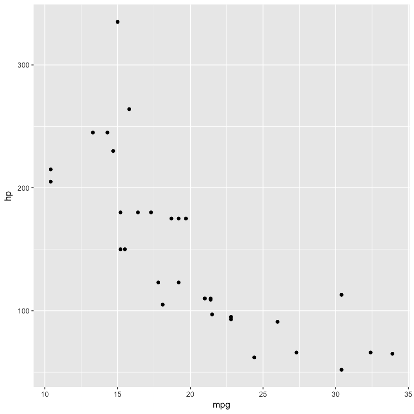

```r
ggplot(mtcars,aes(x = mpg, y = hp))+geom_point()
```

Here mpg is Miles Per Gallon and hp is Horsepower

# Lets change the colors of the datapoints of scatterplot created above

In order to change the color of the scatterplot data points, we need to use color = "red" in geom_point.

Now one can define any color of their choice instead of red. Lets write the code and see the result.

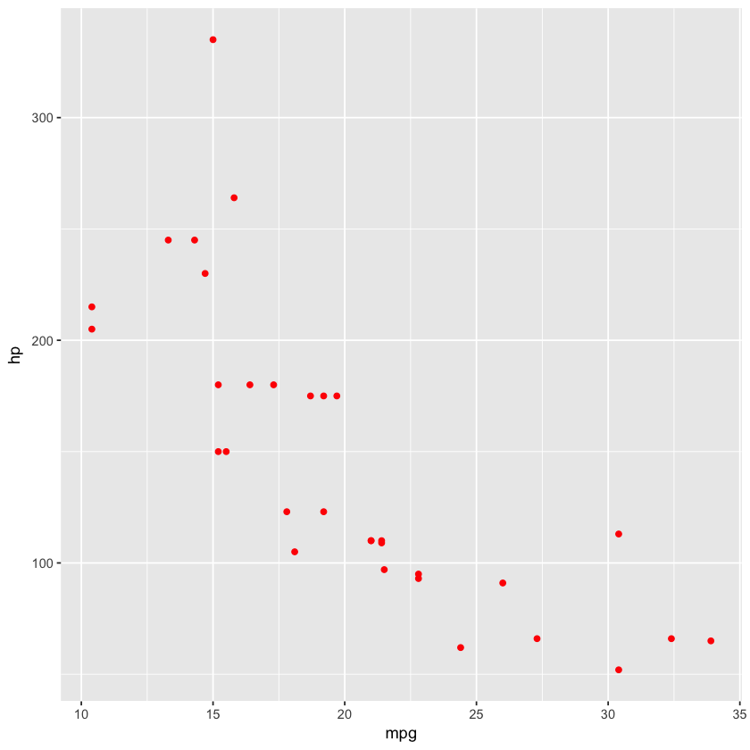

```r
ggplot(mtcars,aes(x = mpg, y = hp))+geom_point(color = "red")
```

# Can We Change the Size of the Datapoints...Lets See if this can be done...

Now just like the way we have changed the color of the datapoints, similarly we can use geom_point(size = 2.5)

Tip - Try to keep the points between 1 to 5 unless very large datapoints are required.

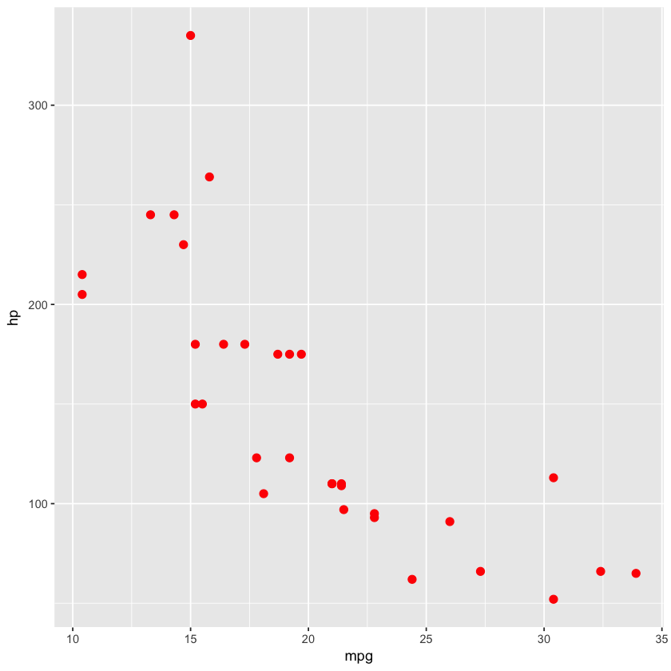

```r
ggplot(mtcars,aes(x = mpg, y = hp))+geom_point(color = "red", size = 2.5)
```

# Shape and Size of Data Points in Scatterplot

Ok, so now we have seen that we can change the color of the datapoints. Now,can we change the size and shape of the datapoints. Lets see if this can be done.

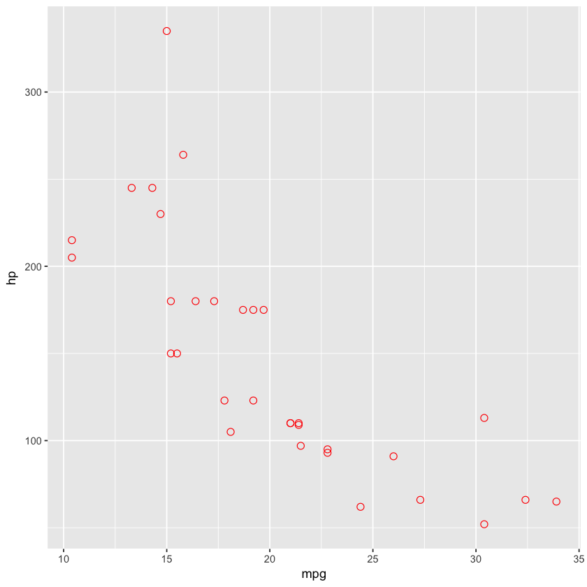

```r
ggplot(mtcars,aes(x = mpg, y = hp))+geom_point(color = "red", size = 2.5, shape = 1)
```

The point worth noting in above plot is as we passed the parameter "shape = 1", the datapoints shape converted from opaque dots to hollow circles. There are lots of shapes and codes available in the google drive which is available under the following link:

https://drive.google.com/file/d/1eiw6ltlYxXojAv3eG6byqhyaWYE7OplB/view?usp=sharing

# Background of the Plot

If you wish to change the background of the plot, we can use theme_classic() to do the job.

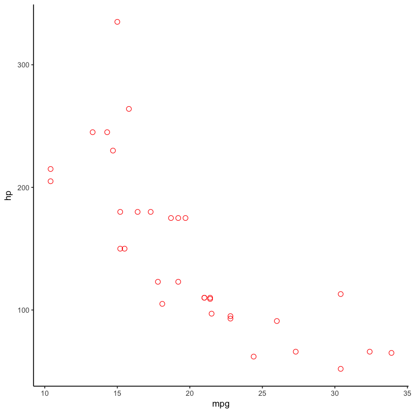

```r
ggplot(mtcars,aes(x = mpg, y = hp))+geom_point(color = "red", size = 2.5, shape = 1)+theme_classic()
```

# Lets Put Labels on the Scatterplot

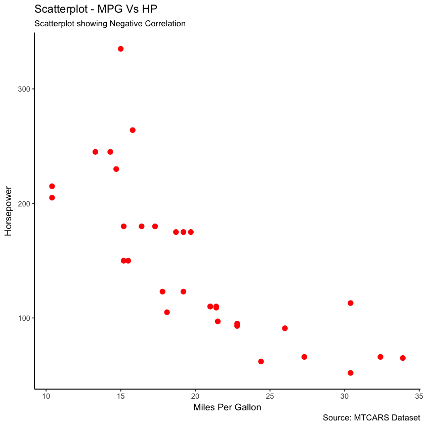

```r
ggplot(mtcars,aes(x = mpg, y = hp))+geom_point(color = "red", size = 2.5)+theme_classic()+
labs(title = "Scatterplot - MPG Vs HP",
    subtitle = "Scatterplot showing Negative Correlation",
    x = "Miles Per Gallon",
    y = "Horsepower",
    caption = "Source: MTCARS Dataset")
```

Here Labs is a command that adds labels to the plot. Referring to the above plot

title - Main Title of the Plot

subtitle - Text Below the Main Title

x - X Axis Label

y - Y Axis Label

caption - Providing Info about the Plot. Shown in the Bottom Right Corner of the Plot

# Lets Put the Color on the Plot basis the Column Values

In order to color the plot basis column values, we have to define the column name is Aesthetics. Lets See how this can be done.

# MTCARS Data - Color the Datapoints basis Cylinder Column Values.

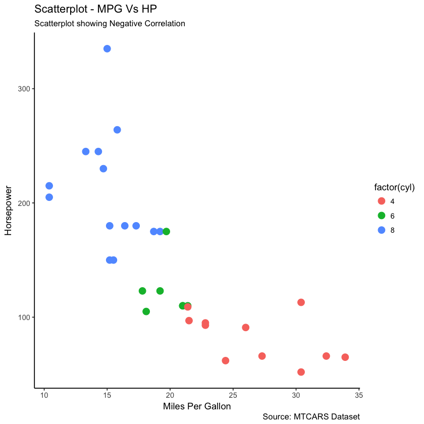

```r
ggplot(mtcars,aes(x = mpg, y = hp))+
geom_point(aes(color = factor(cyl)), size = 3.5)+
theme_classic()+ labs(title = "Scatterplot - MPG Vs HP",
    subtitle = "Scatterplot showing Negative Correlation",
    x = "Miles Per Gallon",
    y = "Horsepower",
    caption = "Source: MTCARS Dataset")
```

Moreover, factor(cyl) is taken because cylinder column has only 03 types of values namely 4, 6 and 8 cylinders.

# Similarly, we can change the shape and size of the datapoints in the scatterplot. Lets see how this can done....

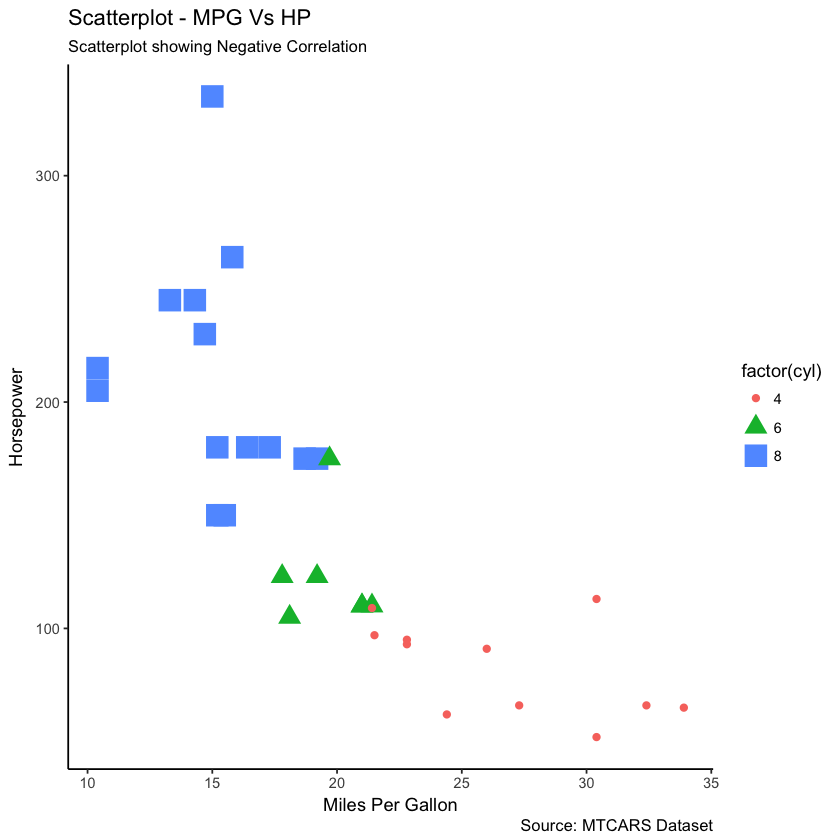

```r
ggplot(mtcars,aes(x = mpg, y = hp))+
geom_point(aes(color=factor(cyl), shape = factor(cyl),size = factor(cyl)))+
theme_classic()+ labs(title = "Scatterplot - MPG Vs HP",
    subtitle = "Scatterplot showing Negative Correlation",
    x = "Miles Per Gallon",
    y = "Horsepower",
    caption = "Source: MTCARS Dataset")
```

Thus, it can be seen that using aesthetics and defining the color, shape and size basis column values change the entire appearance of the plot and becomes easy to interpret.

This is the first part of the tutorial. More Tutorials to Follow Soon.